# prelim_results

Keana Richards

# 1 Summary:

- Final sample N = 203
- All graphs represent 95% CIs
- Our primary hyp was supported 😄, where gender & condition interacted to affect subjective confidence (aka how confident participants felt about performing well on the upcoming multiplication task). Graph suggests that women have a boost in subjective confidence in preparation condition relative to control, while men’s confidence actually *decreases* in preparation condition relative to control. Even though women are still less confident than men in the preparation condition, the gender difference in subjective confidence is smaller in preparation condition relative to control condition.
- However, when it comes to absolute confidence (aka how many questions participants thought they answered correctly on the multiplication task), the interaction between gender and condition doesn’t replicate: we only find evidence of an effect of gender on absolute confidence, where, unsurprisingly based on previous research, women think they will complete significantly fewer problems compared to men (although after correcting for MHT, the effect of gender is only marginally significant *p* = .09). There are a couple of possible reasons that we didn’t replicate the interaction effect between gender and condition: 1) the effects of preparation on absolute confidence are qualitatively distinct from the effects of subjective confidence and/or 2) absolute confidence is measured AFTER the main task, so it may be timing that matters. Or possibly a combination of both: e.g., women may try to avoid appearing overconfident in trying to guess how many questions they got right, so they underestimate, *especially* after completing the task already (which means they can’t blame the uncertainty of future performance on doing poorly). With subjective confidence, there is no standard by which they can be judged as overconfident, so they don’t have to worry as much for being judged as overconfident if they say they *feel* more confident. Also, since subjective confidence is measured before the main task, there is still uncertainty surrounding their future performance, so there is still even less reason to avoid being overconfident, since they can point to uncertainty as an explanation…. but this is just post-hoc theorizing 😅
- Notably, women have no specific reason for feeling less confident than men overall: there were no gender differences in performance on the main task.
- At the same time, we don’t find evidence that condition actually affected performance, so the fact that women’s subjective confidence increased in preparation condition even though they weren’t actually performing better is in favor of our idea of opportunity costs: women may prepare more than men, even past the point where preparation boosts performance, just because it makes them feel more confident (even if just in subjective, rather than absolute, terms) about entering a competition/completing a task. Relatedly, we don’t find evidence of a gender difference in beliefs about the benefits of preparation among participants in the control condition - again suggesting that women are not especially prone to believe that preparation boosts performance, but may still engage in it more for the benefits on subjective confidence. Or another explanation might be that women just feel like they should prepare more because they are expected to do so based on gender norms, which we have evidence for (i.e., participants, especially women, are significantly more likely to believe that women prepare more than men for most tasks) - however, this gender norms explanation doesn’t seem to explain why women see a boost in subjective confidence as shown in the primary hypothesis.
- We rule out a possible explanation for gender differences in preparation: there do not appear to be any significant gender differences in interest in the task, so it is unlikely that women prepared more in the past because they thought the task was inherently more interesting.
- When we asked participants to rank the possible explanations for gender differences in preparation, they were most likely to say that “women believe practice will improve performance more than men” and least likely to say that “women have more free time to devote to practicing than men” - where participants’ responses to the free time option is in favor of our opportunity costs idea.
- Noteworthy confound: there is evidence of a significant difference between time spent on multiplication task (prep condition) vs addition task (control condition).

# 2 Pre-registered analyses:

## 2.1 Primary hypothesis 1:

- Model: Linear regression
1. Predictor(s): Condition, gender, gender*condition
2. Outcome: Subjective confidence
- Evidence of effects of gender, $b = -14.81$, 95% CI $[-21.96$, $-7.65]$, $t(189) = -4.08$, $p < .001$, and gender*condition, $b = 13.10$, 95% CI $[2.95$, $23.25]$, $t(189) = 2.55$, $p = .012$
- No evidence of effects of condition, $b = -4.34$, 95% CI $[-11.64$, $2.97]$, $t(189) = -1.17$, $p = .243$

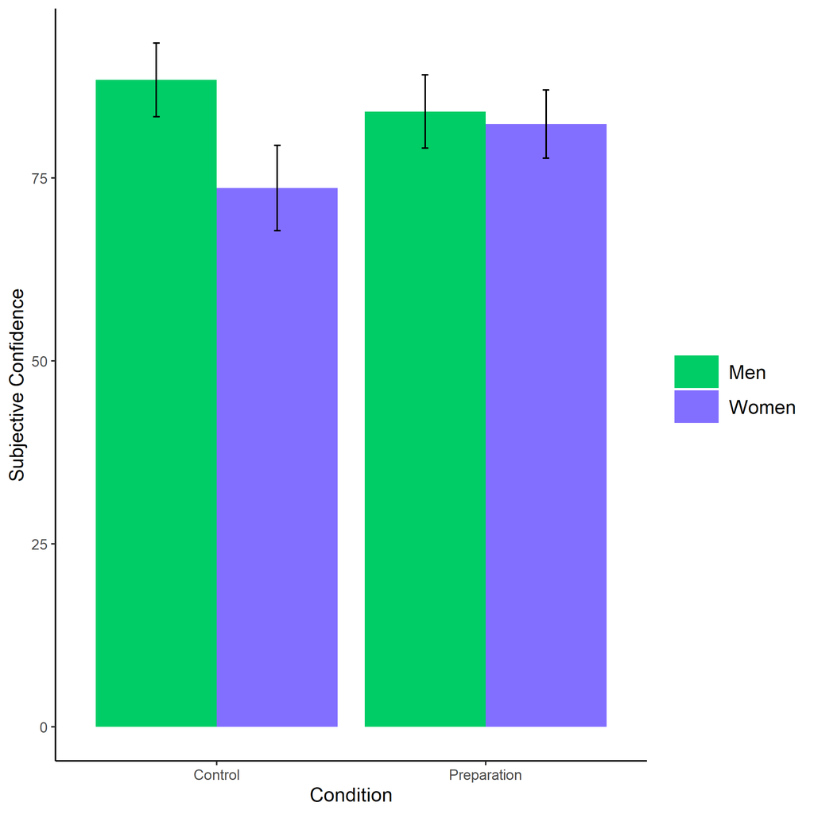

Mean ratings of subjective confidence as a function of gender and condition. Error bars represent 95 percent confidence intervals.

```r
knitr::include_graphics(here::here("study3", "figs","fig00_subj-conf-gender-by-cond.png"))
```

## 2.2 Exploratory analysis 1:

- Model: Linear regression
1. Predictor(s): Condition, gender, gender*condition
2. Outcome: Performance on the main multiplication task
- No evidence of effects of gender, $b = -1.22$, 95% CI $[-8.05$, $5.61]$, $t(192) = -0.35$, $p = .725$, condition, $b = 0.75$, 95% CI $[-6.18$, $7.69]$, $t(192) = 0.21$, $p = .830$, or gender*condition, $b = -6.52$, 95% CI $[-16.19$, $3.14]$, $t(192) = -1.33$, $p = .184$

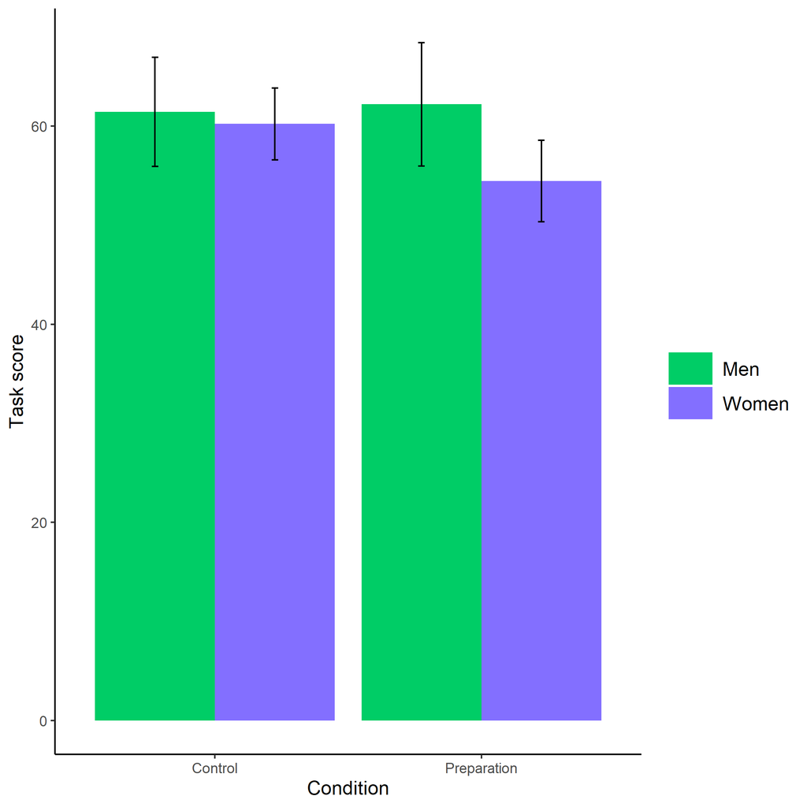

Mean performance on task as a function of gender and condition. Error bars represent 95 percent confidence intervals.

```r
knitr::include_graphics(here::here("study3","figs","fig01_task_score-gender-by-cond.png"))
```

## 2.3 Exploratory analysis 2:

- Model: Linear regression
1. Predictor(s): Condition, gender, gender*condition
2. Outcome: Absolute confidence
- Evidence of effects of gender, $b = -7.16$, 95% CI $[-13.69$, $-0.62]$, $t(184) = -2.16$, $p = .032$ (after adjusting for MHT: *p* = 0.09)
- No evidence of effects of condition, $b = -0.63$, 95% CI $[-7.27$, $6.01]$, $t(184) = -0.19$, $p = .851$ or gender*condition, $b = -2.68$, 95% CI $[-11.92$, $6.56]$, $t(184) = -0.57$, $p = .568$

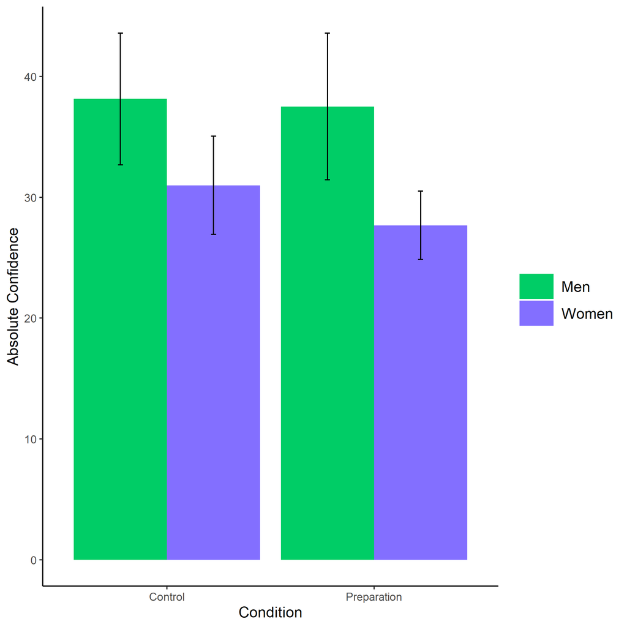

Mean ratings of absolute confidence as a function of gender and condition. Error bars represent 95 percent confidence intervals.

```r
knitr::include_graphics(here::here("study3","figs","fig02_abs-conf-gender-by-cond.png"))
```

## 2.4 Exploratory analysis 3:

3. Model: T-test
1. Predictor(s): Gender
2. Outcome: Interest in the main multiplication task
- No evidence of effects of gender on interest, $\Delta M = -0.14$, 95% CI $[-0.54$, $0.25]$, $t(179.65) = -0.72$, $p = .473$

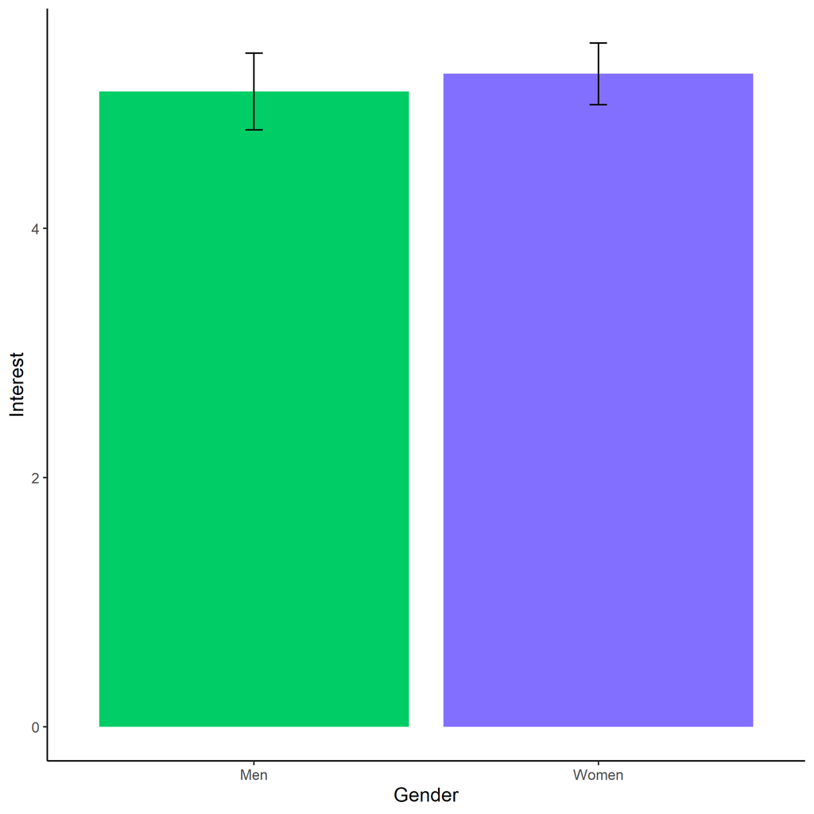

Mean ratings of interest in task by gender. Error bars represent 95 percent confidence intervals.

```r
knitr::include_graphics(here::here("study3","figs","fig03_interest-by-gender.png"))
```

## 2.5 Exploratory analysis 4:

4. Model: Chi-square goodness of fit test (collapsed across conditions) with perceptions of gender differences in performance on the main multiplication task as variable
- Evidence that there is significant difference in proportion of people across categories, $\chi^2(2, n = 203) = 77.28$, $p < .001$ (after adjusting for MHT: *p* < .001), figure suggests that people were far more likely to choose “No difference” in performance

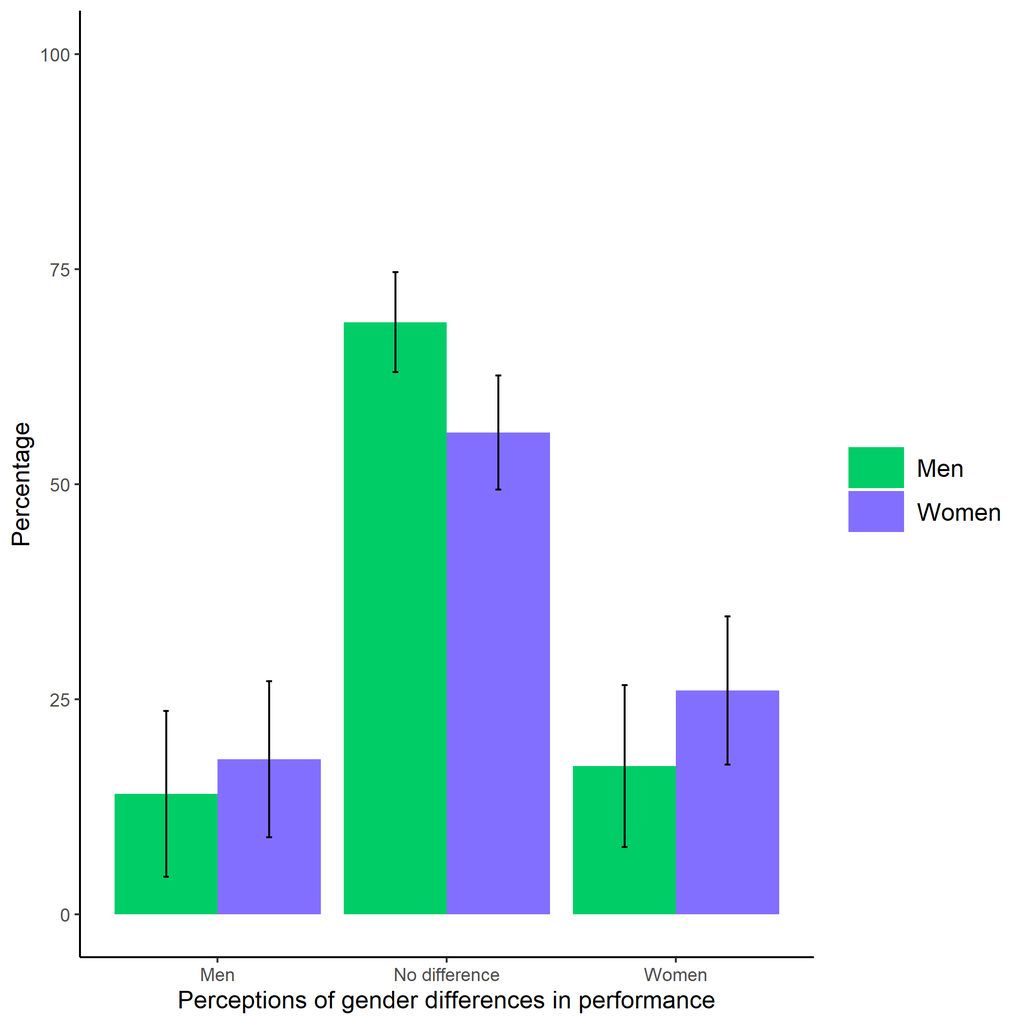

Proportion of participants who thought that women performed better, men performed better, or there were no gender differences in performance on the multiplication task, based on their respective gender. Error bars represent 95 percent confidence intervals.

```r
knitr::include_graphics(here::here("study3","figs","fig04_better-gender-guess.png"))
```

```r
print(ctable(droplevels(gender_filter$gender), gender_filter$better_gender_guess, useNA = "no"))
```

Cross-Tabulation, Row Proportions  
droplevels(gender_filter$gender) * better_gender_guess

|  | better_gender_guess | Men | No difference | Women | Total |
| --- | --- | --- | --- | --- | --- |
| droplevels(gender_filter$gender) |  |  |  |  |  |
| Man |  | 13 (14.0%) | 64 (68.8%) | 16 (17.2%) | 93 (100.0%) |
| Woman |  | 18 (18.0%) | 56 (56.0%) | 26 (26.0%) | 100 (100.0%) |
| Total |  | 31 (16.1%) | 120 (62.2%) | 42 (21.8%) | 193 (100.0%) |

## 2.6 Exploratory analysis 5:

5. Model: Chi-square goodness of fit test (collapsed across conditions) with perceptions of gender differences in willingness to prepare before completing math tasks as variable
- Evidence that there is significant difference in proportion of people across categories, $\chi^2(2, n = 203) = 64.60$, $p < .001$ (after adjusting for MHT: *p* < .001), figure suggests that women are far more likely to say they prepare for math tasks than men, while men are far more likely to say there is no gender difference in the choice to prepare for math tasks

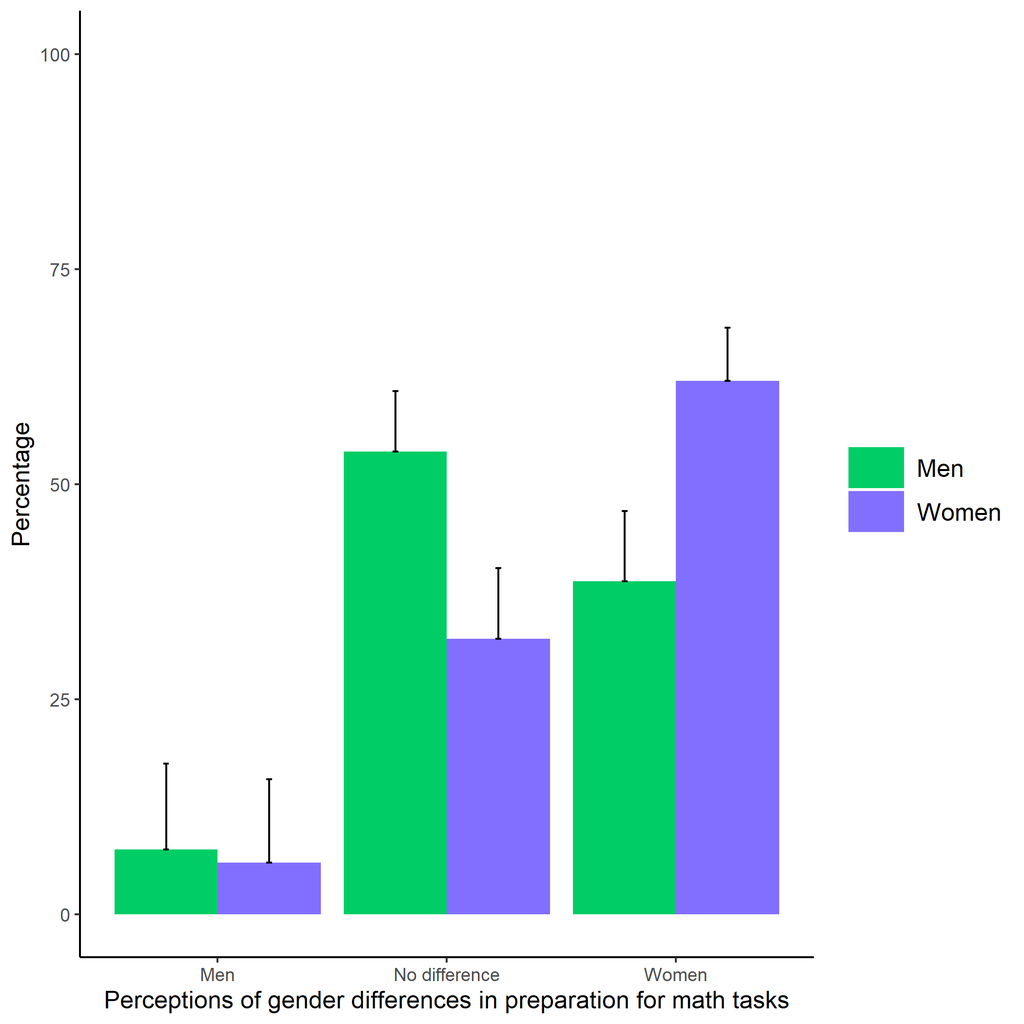

Proportion of participants who thought that women prepare more, men prepare more, or there are no gender differences in preparation before math tasks, based on their respective gender. Error bars represent 95 percent confidence intervals.

```r
knitr::include_graphics(here::here("study3","figs","fig05_perc-math-gender-pract.png"))
```

```r
print(ctable(droplevels(gender_filter$gender), gender_filter$math_gender_prep, useNA = "no"))
```

Cross-Tabulation, Row Proportions  
droplevels(gender_filter$gender) * math_gender_prep

|  | math_gender_prep | Men | No difference | Women | Total |
| --- | --- | --- | --- | --- | --- |
| droplevels(gender_filter$gender) |  |  |  |  |  |
| Man |  | 7 (7.5%) | 50 (53.8%) | 36 (38.7%) | 93 (100.0%) |
| Woman |  | 6 (6.0%) | 32 (32.0%) | 62 (62.0%) | 100 (100.0%) |
| Total |  | 13 (6.7%) | 82 (42.5%) | 98 (50.8%) | 193 (100.0%) |

## 2.7 Exploratory analysis 6:

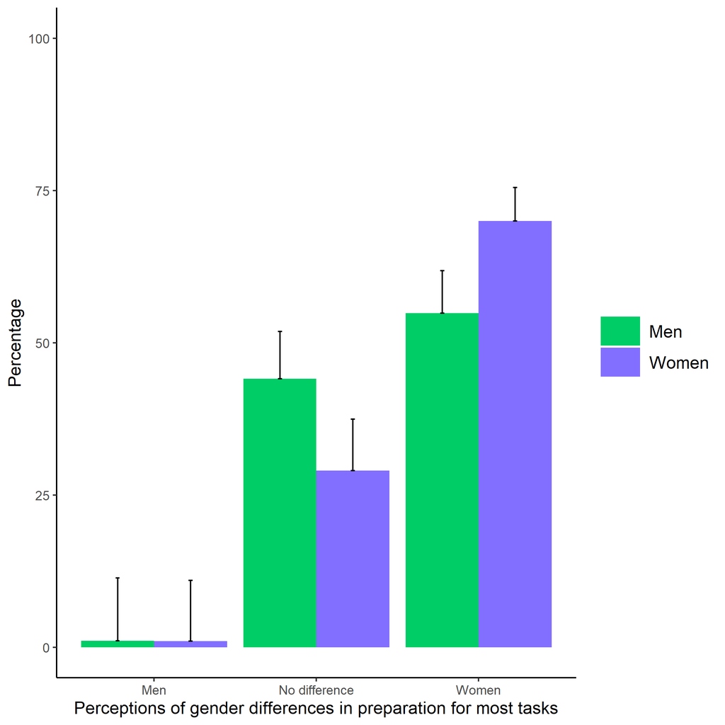

Proportion of participants who thought that women prepare more, men prepare more, or there are no gender differences in preparation before most tasks, based on their respective gender. Error bars represent 95 percent confidence intervals.

```r
knitr::include_graphics(here::here("study3","figs","fig06_perc-gen-gender-pract.png"))
```

```r
print(ctable(droplevels(gender_filter$gender), gender_filter$gen_gender_prep, useNA = "no"))
```

Cross-Tabulation, Row Proportions  
droplevels(gender_filter$gender) * gen_gender_prep

|  | gen_gender_prep | Men | No difference | Women | Total |
| --- | --- | --- | --- | --- | --- |
| droplevels(gender_filter$gender) |  |  |  |  |  |
| Man |  | 1 (1.1%) | 41 (44.1%) | 51 (54.8%) | 93 (100.0%) |
| Woman |  | 1 (1.0%) | 29 (29.0%) | 70 (70.0%) | 100 (100.0%) |
| Total |  | 2 (1.0%) | 70 (36.3%) | 121 (62.7%) | 193 (100.0%) |

## 2.8 Exploratory analysis 7:

7. Model: T-test
1. Predictor(s): Gender
2. Outcome: Performance on the main multiplication task
- No evidence of effects of gender on performance on task, $\Delta M = 4.42$, 95% CI $[-0.71$, $9.55]$, $t(171.74) = 1.70$, $p = .091$

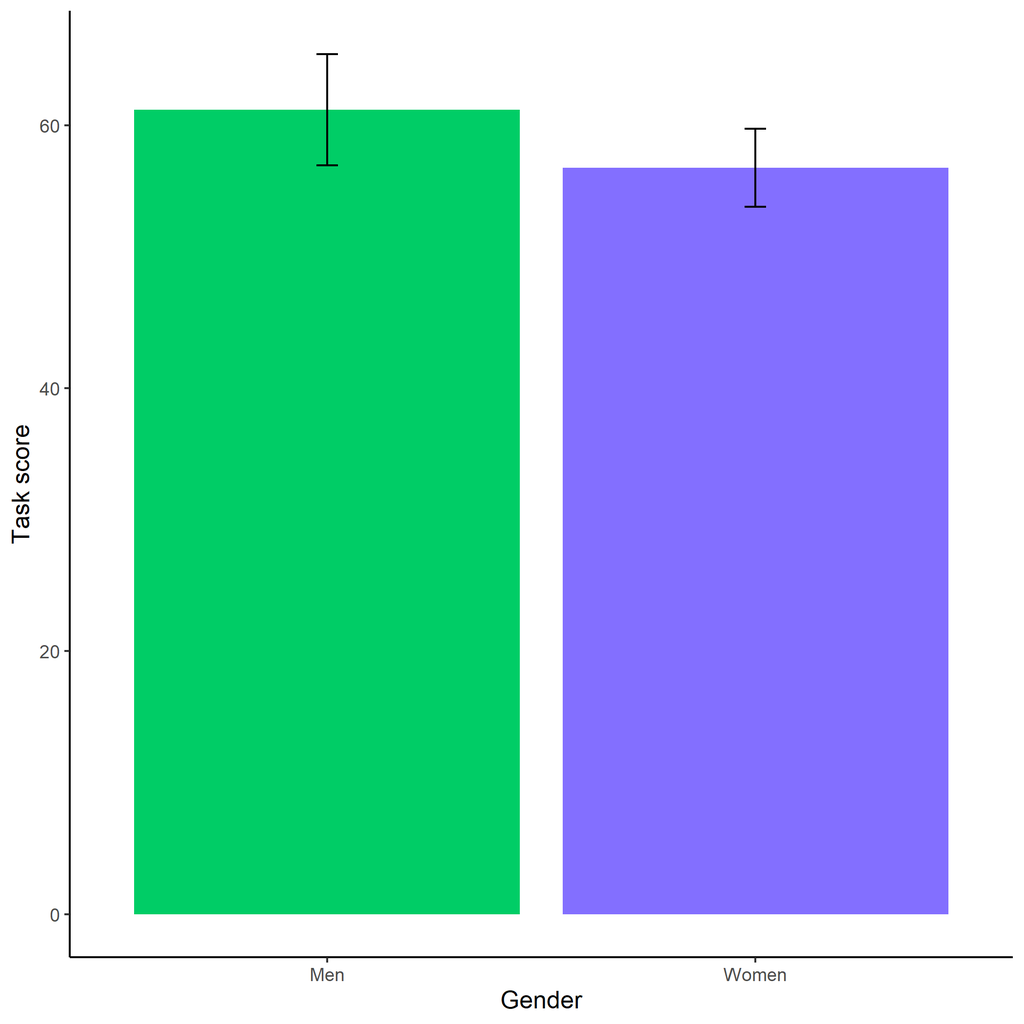

Mean task score based on participant gender. Error bars represent 95 percent confidence intervals.

```r
knitr::include_graphics(here::here("study3","figs","fig07_task_score-by-gender.png"))
```

## 2.9 Exploratory analysis 8:

8. Model: T-test
1. Predictor(s): Condition
2. Mediator: Absolute Confidence
- No evidence of effects of condition on absolute confidence, $\Delta M = 1.98$, 95% CI $[-2.72$, $6.68]$, $t(189.00) = 0.83$, $p = .406$

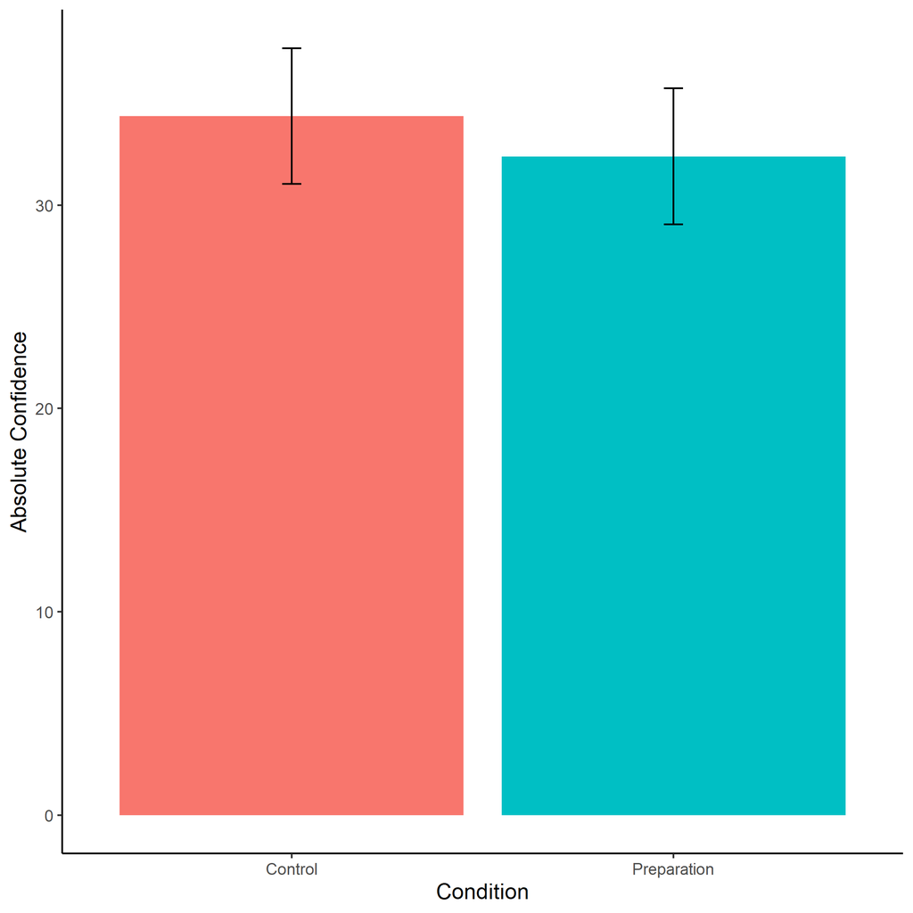

Mean absolute confidence based on condition. Error bars represent 95 percent confidence intervals.

```r
knitr::include_graphics(here::here("study3","figs","fig08_abs-conf-by-condition.png"))
```

## 2.10 Exploratory analysis 9:

9. Model: Mediation
1. Predictor(s): Condition
2. Mediator: Subjective Confidence
3. Outcome: Performance on main multiplication task
- No evidence of effects of condition on task score, $b = -1.91$, 95% CI $[-6.83$, $3.01]$, $t(198) = -0.77$, $p = .445$, so did not run rest of mediation model

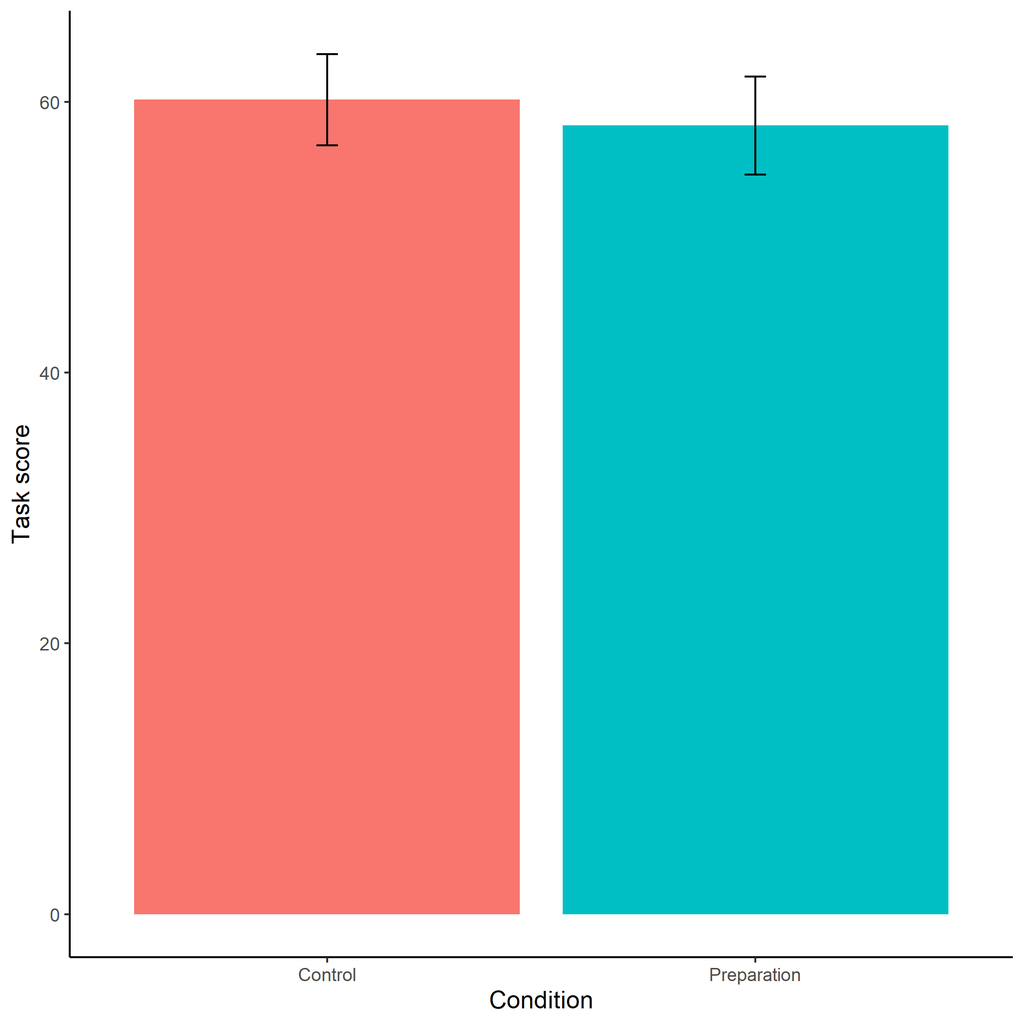

Mean task score based on condition. Error bars represent 95 percent confidence intervals.

```r
knitr::include_graphics(here::here("study3","figs","fig09_task-score-by-condition.png"))
```

## 2.11 Exploratory analysis 10:

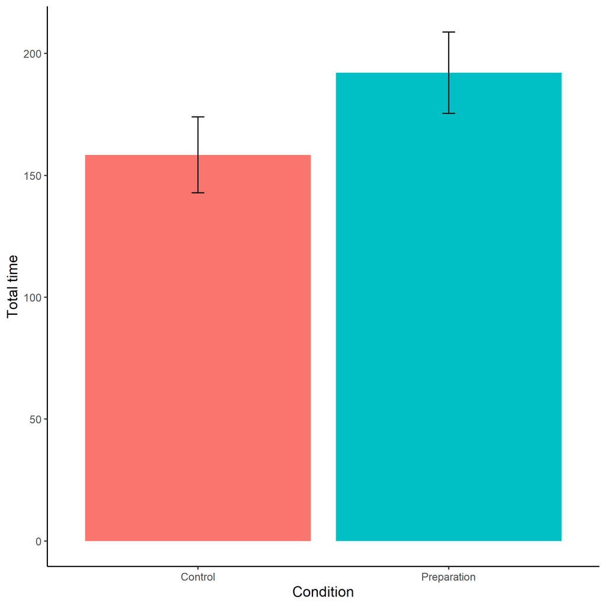

Mean time spent on task based on condition. Error bars represent 95 percent confidence intervals.

```r
knitr::include_graphics(here::here("study3","figs","fig10_total-time-by-condition.png"))
```

## 2.12 Exploratory analysis 11:

11. Model: T-test
1. Predictor(s): Gender Outcome: Beliefs about the effects of preparation on performance Note: this analysis will only include participants from the control condition
- No evidence of effects of gender on beliefs about effects of preparation on performance, $\Delta M = -0.44$, 95% CI $[-1.17$, $0.29]$, $t(86.37) = -1.19$, $p = .235$

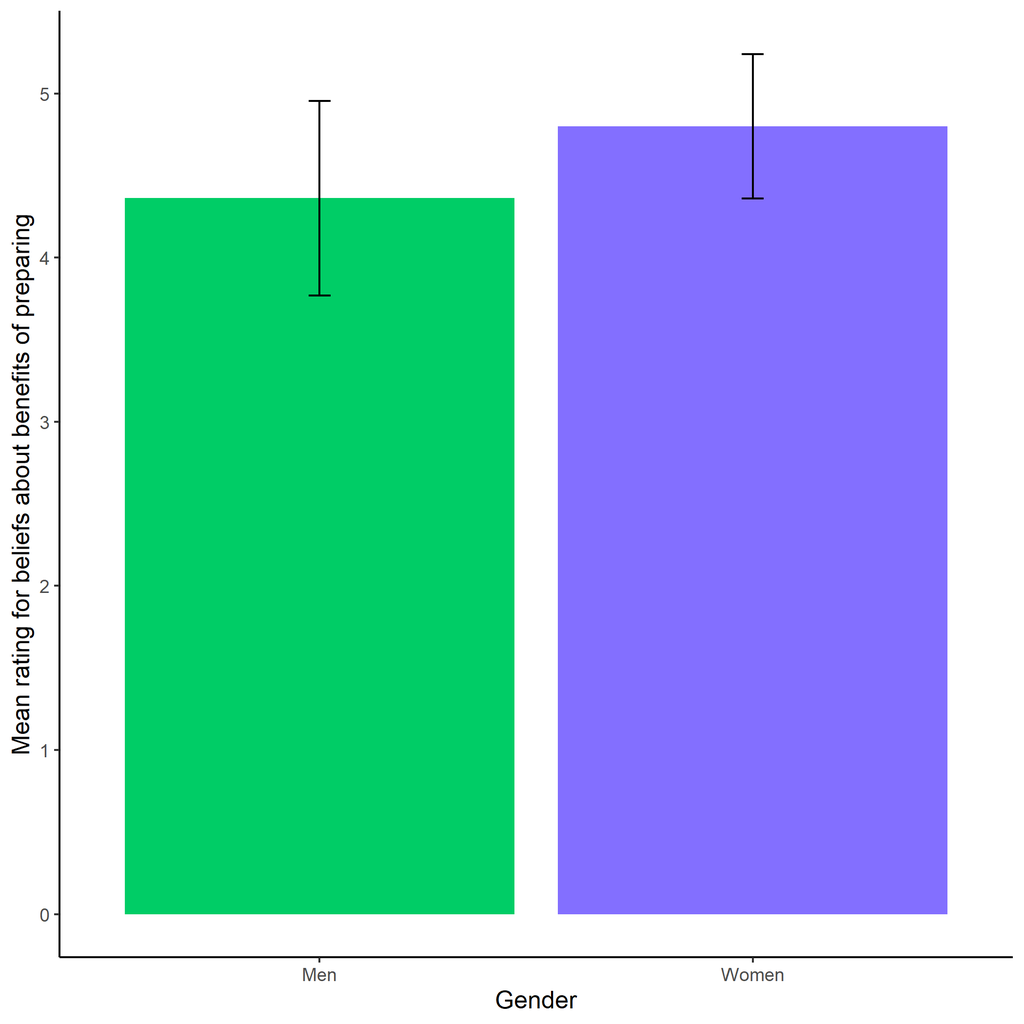

```r
knitr::include_graphics(here::here("study3","figs","fig11_control-prep-beliefs-by-gender.png"))
```

## 2.13 Exploratory analysis 12:

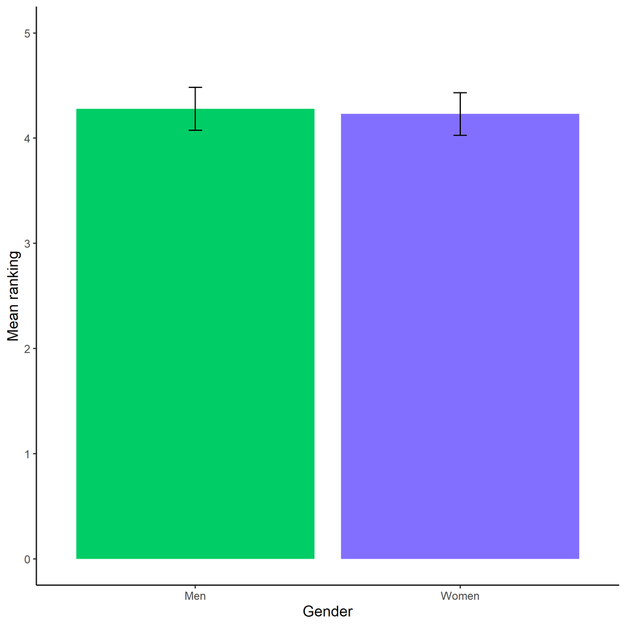

Mean ranking that ‘Women are more likely to think that practicing will improve their performance on the multiplication task compared to men’ explains previously observed gender differences as a function of participant gender. Error bars represent 95 percent confidence intervals.

```r
knitr::include_graphics(here::here("study3","figs","fig12_gender_rank_explanations_2.png"))
```

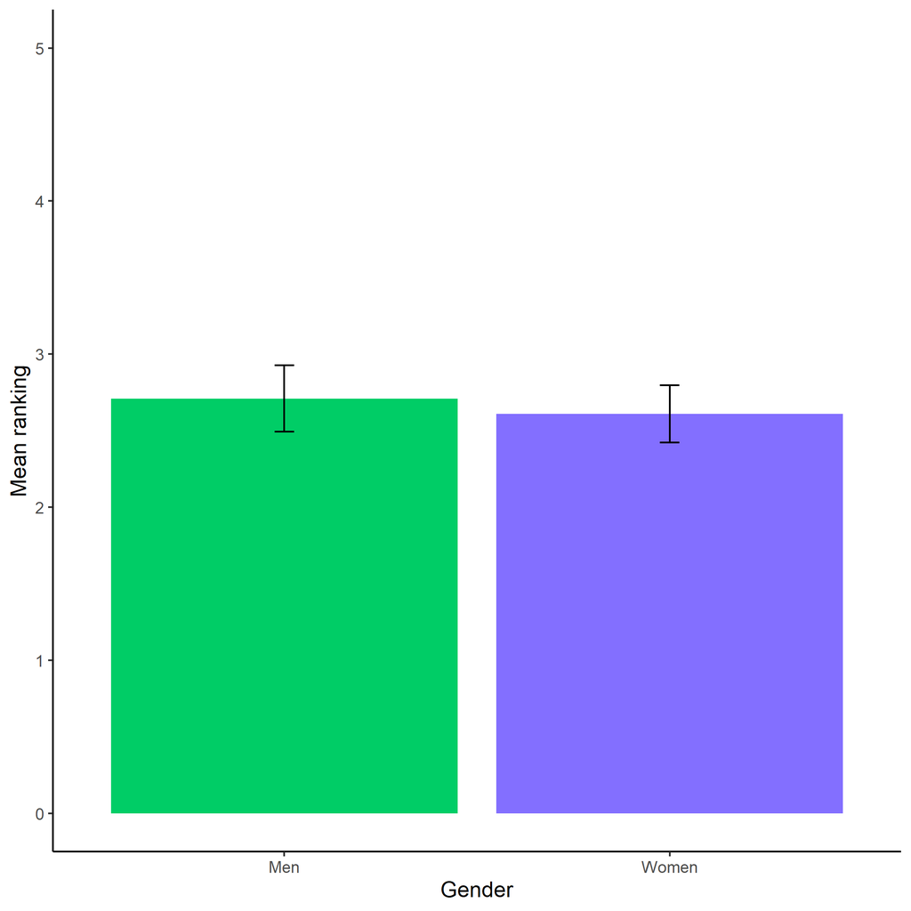

Mean ranking that ‘Women enjoy practicing for the multiplication problems more than men’ explains previously observed gender differences as a function of participant gender. Error bars represent 95 percent confidence intervals.

```r
knitr::include_graphics(here::here("study3","figs","fig13_gender_rank_explanations_4.png"))
```

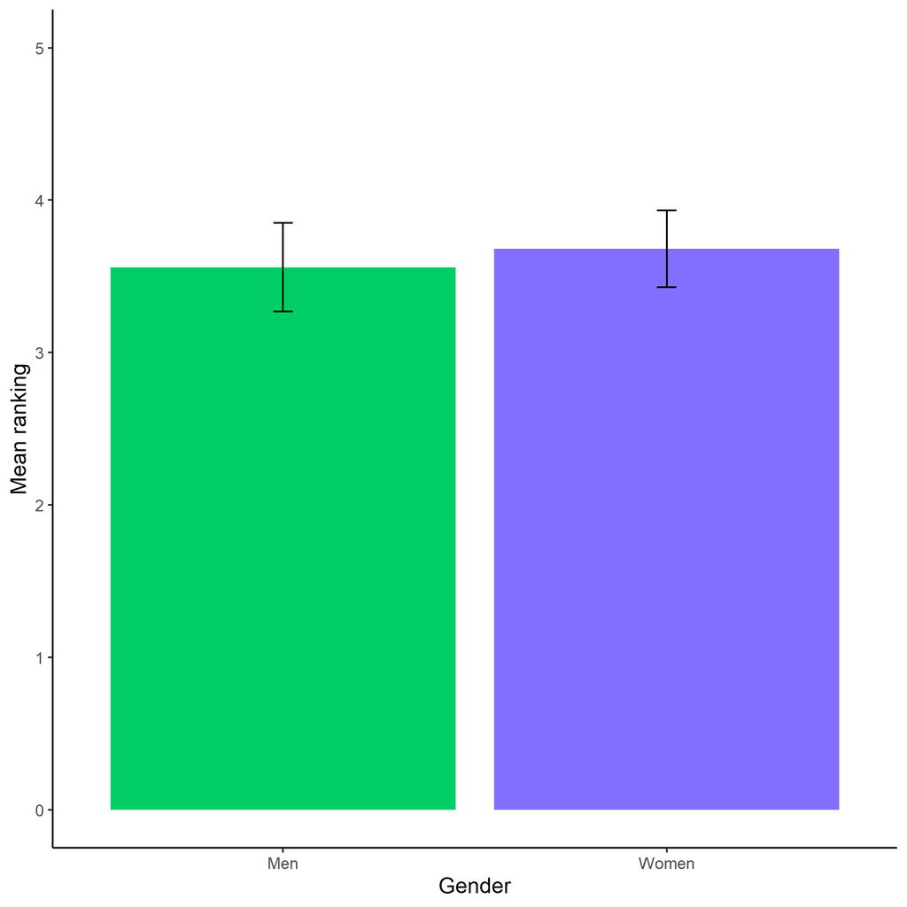

Mean ranking that ‘Women are less confident that they will perform well on the multiplication task compared to men’ explains previously observed gender differences as a function of participant gender. Error bars represent 95 percent confidence intervals.

```r
knitr::include_graphics(here::here("study3","figs","fig14_gender_rank_explanations_5.png"))
```

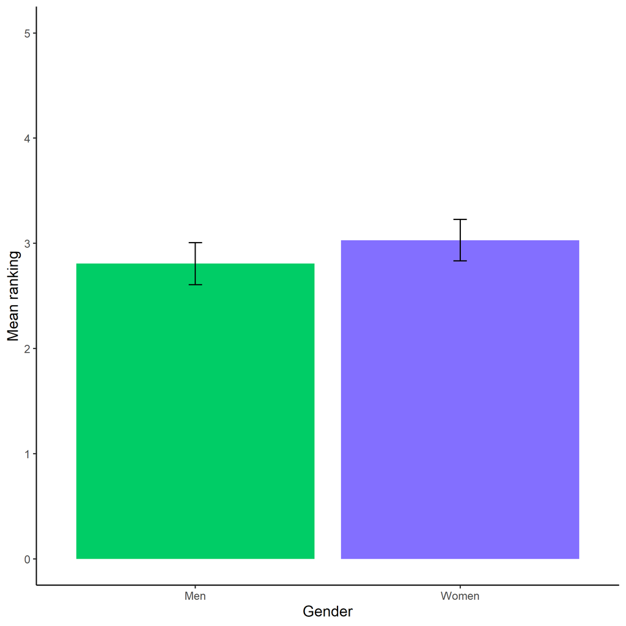

Mean ranking that ‘Women enjoy the process of mastering their multiplication tables more than men’ explains previously observed gender differences as a function of participant gender. Error bars represent 95 percent confidence intervals.

```r
knitr::include_graphics(here::here("study3","figs","fig15_gender_rank_explanations_6.png"))
```

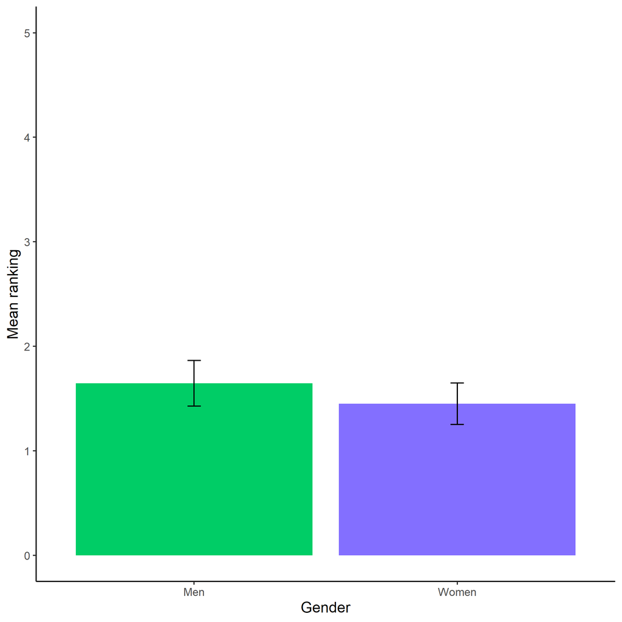

Mean ranking that ‘Women have more free time to devote to practicing for the multiplication task than men’ explains previously observed gender differences as a function of participant gender. Error bars represent 95 percent confidence intervals.

```r
knitr::include_graphics(here::here("study3","figs","fig16_gender_rank_explanations_8.png"))
```

# 3 Free-response explanations for gender differences in previous studies:

When asked what other explanations there might be, here’s what participants said:

```r
clean %>% dplyr::select(text_explanation) %>% filter(is.na(text_explanation) == FALSE & text_explanation != "n/a"& text_explanation != "no" &text_explanation != "N/A" & text_explanation != "I cannot think of other reasons" & text_explanation != "I do not have any other explanations" & text_explanation != "none")  %>% knitr::kable()
```

| text_explanation |
| --- |
| I think there may be a gender difference (biased towards men) in the majors/career paths that require STEM knowledge and arithmetic mastery. Therefore, men’s scores may slightly exceed women’s, on ave… |
| Men are more overly confident in their abilities for simple things such as multiplication (even if they do not have reason to be), whereas women acknowledge that they should not be cocky about their a… |
| there is a societal perception that men are better than women at maths, therefore they might feel inferior to the mens’ abilities at maths and so will study harder to do better |
| The societal expectation that women are worse then men at math makes them try harder. |
| Women have the tendency to feel like they are doing worse at math than their peers when they are doing equal or better than their male peers. |
| to prove men wrong. |
| Women are always told in our society to follow rules by the book, and not take risk like men do. That’s also why I think women an average prepare more. |
| Women feel they have pressure to overcome stereotypes about their gender performance in math |
| Early education unfairly penalizes behavior problems of boys. This phenomenon offers a possible explanation as to why women tend to have better study skills and academic success than men. https://www.… |
| I’ve read some studies that showed that women tend to be more agreeable and conscientious in terms of personality traits than men. It makes sense to me that when asked to prepare more, women would bot… |
| Women are more likely to recognize the merits of practicing. |
| Women in general care more about performing well |
| Women are more thoughtful at the task at hand than men. |
| Men are overconfident in their skills. |
| Perhaps men are more impulsive and overconfident. |
| Women are just as good at math at men, but society tells them that they’re meant to be worse. If anything, women study more math to counteract this fact or avoid it because they’re told they should, b… |
| Women have a better memory than men |
| There is the stereotype threat saying women are not good at math as man do. |
| probably goes back to when we learned multiplication tables–elementary school. I feel that quick math like this was mastered by the girls before the boys in class because of differences in maturity at… |
| Men have a higher confidence bias where they feel more prepared than they actually are. Women have less of one thus they study more to increase their performance |